# SwiftKey NLP Capstone - Milestone Report

Farhan Bin Hossain

2026-08-15

## Overview

This report presents a analysis of the SwiftKey Dataset provided by Johns Hopkins and Coursera.

## 1. Data Summary

Dataset Summary

| Source | Lines | Size_MB |
| --- | --- | --- |
| Blogs | 899288 | 200.4 |
| News | 1010242 | 196.3 |
| Twitter | 2360148 | 159.4 |

The dataset is large — over **4 million lines** and **556 MB** of raw text. To keep analysis efficient, a random sample of 10,000 lines per source was used throughout this report.

## 2. Average Words Per Line

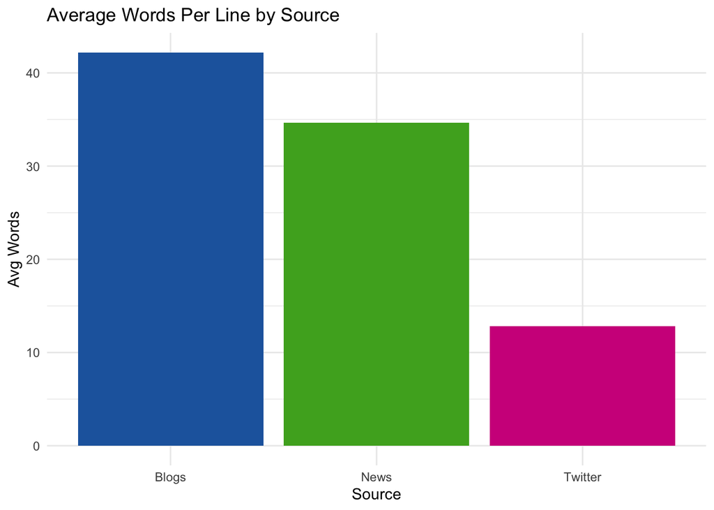

Blogs contain the longest text averaging around **42 words per line**, while Twitter is shortest at around **12 words** due to character limits. This difference will influence how the prediction model handles short vs long context.

## 3. Most Common Words

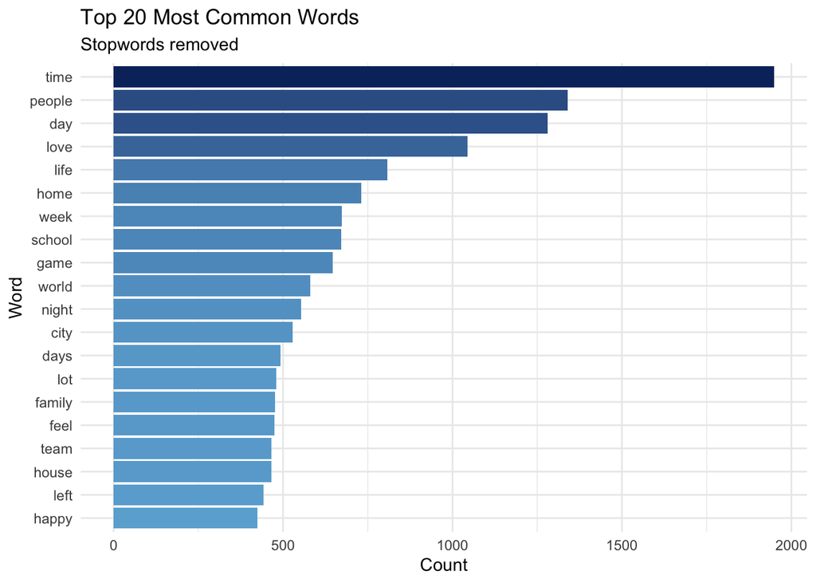

The most frequent words — **time, people, day, love, life** — reflect the personal and conversational nature of the data sources.

## 4. Bigrams (Two-Word Pairs)

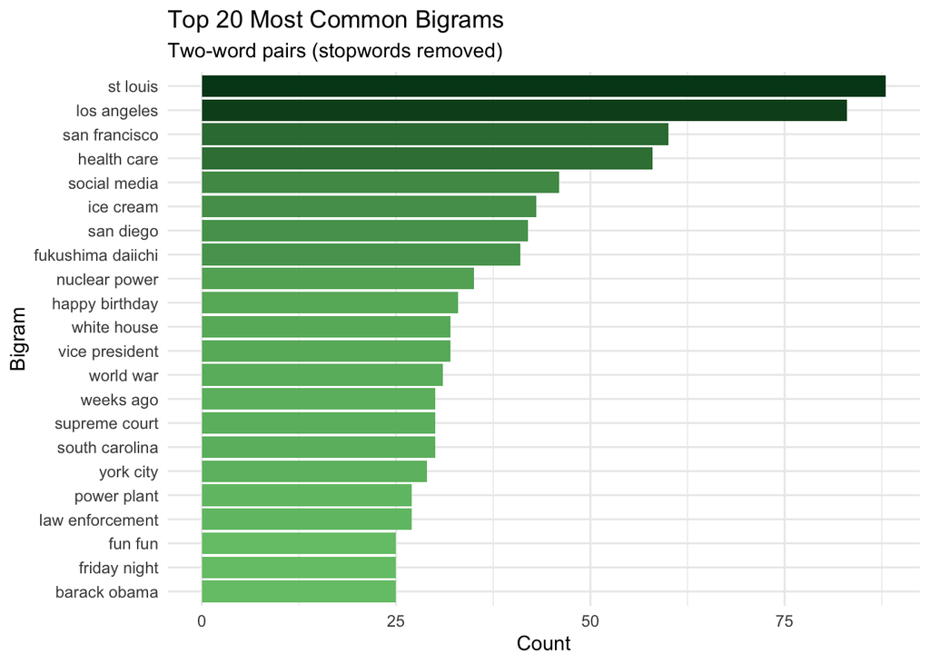

## 5. Trigrams (Three-Word Sequences)

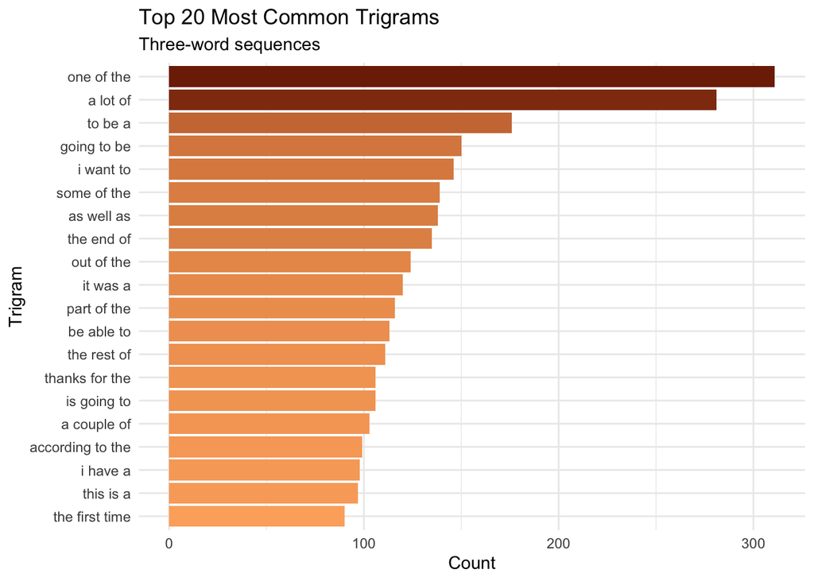

Trigrams like **“one of the”** and **“a lot of”** reveal natural English phrasing patterns that the prediction model will learn from.

## 6. Plan for Prediction Algorithm

The next word prediction model will work like:

1. **N-gram lookup** — When a usir types a word or phrase, the system will compare it with bigrams and trigrams and predict the next word.
2. **Backoff strategy** — If no trigram found, it will go back to bigram then unigram (most common word)
3. **Training** — For better acuracy the model need to be trained on larger dataset.
4. **Cleaning** — filtering and punctuation removal will be applied

## 7. Plan for Shiny App

The Shiny app will:

- Provide a **text input box** where users type a word or phrase
- Instantly display the **top 3 predicted next words**
- Show a simple bar chart of prediction confidence
- Be fast and lightweight by using a pre-computed lookup table

## Conclusion

The analysis confirms the data is rich, diverse, and suitable for building a next word prediction. findings include significant differences in text length across sources, and clear patterns in word and phrase frequency that will directly inform the prediction algorithm.